# **Stacks**

# **Implementasi Stacks**

Berikut adalah contoh implementasi untuk penggunaan stacks, yaitu *delimiter matching* dan konversi desimal ke biner

## **Delimiter Matching**

**Parentheses** sering digunakan untuk urutan penyelesaian dalam persamaan Matematika, seperti contoh berikut:

P = 5 x (4 + 5)/(3 + 2)x(10-8)

Oleh karena itu diperlukan algoritma untuk pemeriksaan parentheses ini atau secara umum **delimiter**, yaitu '{}','[]', dan '()'.

Beberapa tahapan atau algoritma untuk pengecekan *parentheses* ini adalah:

1. Baca setiap karakter yang terdapat pada suatu string matematika
2. Jika karakter adalah kurung buka, maka masukkan dalam stack
3. Jika karakter adalah tutup, ada beberapa kondisi yang harus diperika, yaitu:
   - Jika stack dalam keadaan empty, maka jumlah kurng tutup lebih banyak daripada kurung siku
   - Jika stack dalam keadaan tidak empty, maka pop stack, dan cocokkan karakter hasil pop dengan kurung tutup, jika sejenis, maka *matched*, jika tidak maka jenis kurung tidak sama
4. Jika semua karakter telah terbaca, dan stack masih dalam keadaan terisi (tidak empty), maka jumlah kurung buka lebih banyak daripada kururng tutup

```python
def checkParentheses(strMat):
    data = stack()
    for ch in strMat:
        if ch == '(':
            push(data,ch)
        elif ch == ')':
            if isEmpty(data):
                return 'kelebihan kurung tutup'
            else:
                pop(data)
    if isEmpty(data):
        return True
    else:
        return 'Kelebihan kurung buka'
```

```python
checkParentheses('5 x (4 + 5) / (3 + 2) x (10 - 8)')
```

```
True
```

```python
a='5 x (4 + 5) / (3 + 2) x (10 - 8))'
'300' in a
```

```
False
```

# Code

Berikut adalah fungsi untuk pengecekan kurung pada suatu string matematika

```python
def stack():
    s = []
    return (s)
def push(s,data):
    s.append(data)
def pop(s):
    data = s.pop()
    return (data)
def peek(s):
    return (s[len(s)-1])
def isEmpty(s):
    return (s==[])
def size(s):
    return (len(s))
```

```python
def parenthesesCheck(strMath):
    kurung = {')':'(','}':'{',']':'['}
    kurungBuka=kurung.values()
    kurungTutup=kurung.keys()
    temp=stack()
    matched=True
    for ch in strMath:
        if ch in kurungBuka:
            push(temp,ch)
        if ch in kurungTutup:
            if isEmpty(temp):
                return 'Kelebihan kurung Tutup'
            else:
                tempKurung=pop(temp)
                if tempKurung==kurung[ch]:
                    matched=matched and True
                else:
                    matched=matched and False
    if not(isEmpty(temp)):
        return 'Kelebihan Kurung Buka'
    if matched == True:
        return 'OK'
    else:
        return 'Tidak Cocok Kurungnya'
```

```python
parenthesesCheck('{5+2}*3')
```

```
'OK'
```

```python
def convertBinary(num):
    temp=stack()
    divNum=num
    while divNum>0:
        push(temp,divNum%2)
        divNum=divNum//2
    tempStr=''
    for i in range(size(temp)):
        tempStr=tempStr+str(pop(temp))
    return tempStr

print(convertBinary(25))
```

```
11001
```

```python
def paranthesesCheck(strMath):
    operandStack=stack()
    lenMath=len(strMath)
    openOperand='({['
    closeOperand=')}]'
    i = 0
    Matched = True
    while i<(lenMath):
        if strMath[i] in openOperand:
            push(operandStack,strMath[i])
        elif strMath[i] in closeOperand:
            if not (isEmpty(operandStack)):
                top = pop(operandStack)
                if openOperand.index(top)==closeOperand.index(strMath[i]):
                    Matched=Matched and True
                else:
                    Matched=Matched and False
                    print('Kurung Buka dan Kurung Tutup tidak Cocok')
            else:
                Matched=Matched and False
                print('Jumlah Kurung Tutup lebih banyak')
        i=i+1

    if not(isEmpty(operandStack)):
        Matched=False
        print('Jumlah Kurung Buka Lebih banyak')
    return(Matched)
```

```python
a='5 x (4 + 5) / ((3 + 2) x (10 - 8)'

isMatched=paranthesesCheck(a)
print(isMatched)
```

```
Jumlah Kurung Buka Lebih banyak
False
```

```python
paranthesesCheck('5 x (4 + 5) / ((3 + 2) x (10 - 8))')
```

```
True
```

```python
paranthesesCheck('5 x (4 + 5} / ((3 + 2) x (10 - 8))')
```

```
Kurung Buka dan Kurung Tutup tidak Cocok
```

```
False
```

## Konversi Bilangan

Pada dunia ilmu komputer seringkali dibutuhkan proses konversi dari suatu bilangan ke bilangan lain, misalkan dari bilangan desimal menjadi bilangan biner atau menjadi bilangan octal. Ilustrasi proses konversi dari bilangan desimal ke bilangan biner dapat dilihat pada Gambar 4 berikut.

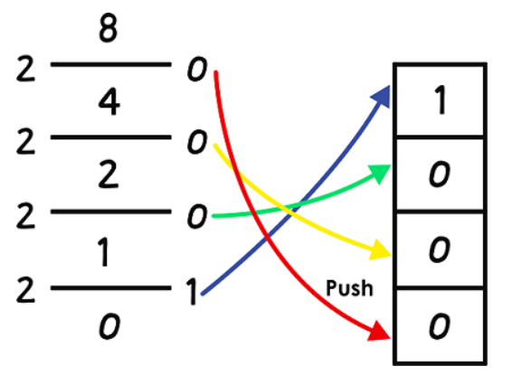

**Gambar 4. Konversi bilangan desimal ke biner**

Dari Gambar tersebut dapat dilihat bahwa bilangan biner didapatkan dari sisa pembagian bilangan desimal dengan dua. Hasil konversi didapatkan dengan cara membaca terbalik semua sisa tersebut.

### Latihan - 2

Buat function untuk mengkonversi bilangan desimal menjadi bilangan biner dengan menggunakan konsep **stack**

```python
def desToBin(num):
    s = stack()
    divNum = num
    while divNum > 0:
        push(s,divNum%2)
        divNum = divNum//2
    temp = ''
    while not (isEmpty(s)):
        temp = temp + str(pop(s))
    return temp
```

```python
print(desToBin(8))
```

```
1000
```

## **Ekpresi Aritmatik Infix, Prefix, Postfix**

Ekpresi aritmatik yang sering diteui adalah operasi aritmatik **infix**. Pada operasi aritmatik **infix** ini, **operator** (+,-,*,/,dll) berada diantara dua buah **operand** (bilangan). Ekspresi aritmatik ini dapat dengan mudah diselesaikan ketika tidak ada ambiguitas, seperti:

$$A + B$$ $$A \ast X$$ $$A - B + C$$

Akan tetapi, ekspressi aritmatik ini akan sulit diselesaikan jika terjadi ambiguitas, seperti ekspressi aritmatik berikut ini:

$$A + B \ast C$$

Pada ekspressi tersebut, terdapat ambiguitas, yaitu apakah A + B diselesaikan terlebih dahulu ataukah B * C yang harus diselesaikan terlebih dahulu. Ambiguitas ini dapat diatasi dengan konsep **operator precedence**. Pada operator precedence, operator-operator dibagi menjadi beberapa level berdasarkan prioritas urutan penyelesaian.

Pada contoh ekspressi aritmatik A + B * C, berdasarkan operator precedence, maka urutan penyelesaian adalah B * C kemudian hasilnya ditambahkan dengan A. Permasalahan terjadi ketika pada ekspressi aritmatik A + B * C, A + B ingin diselesaikan terlebih dahulu. Untuk penyelesaian ekspressi aritmatik yang tidak sesuai dengan urutan operator precedence, maka tanda '( )' sangatlah diperlukan, sehingga operasi tersebut menjadi (A + B) * C.

Tanda '( )' **tidaklah diperlukan** pada ekspressi aritmatik **prefix** dan **postfix**. Pada ekspressi aritmatik **prefix**, operator mendahului operand, sedangkankan ekspressi aritmatik **postfix**, operator ditulis setelah operand.

Berikut contoh ekspresi aritmatik **infix** dan konversinya ke **prefix** dan **postfix**.

$$ \begin{array}{ccc} \mathbf{Infix} & \mathbf{Prefix} & \mathbf{Postfix} \\ \hline A+B & +AB & AB+ \\ (A+B)*C & *+ABC & AB+C* \\ (A+B)*(C-D) & *+AB-CD & AB+CD-* \\ A+B*C-D & -+A*BCD & ABC*+D- \\ A+B-C+D & +-+ABCD & AB+C-D+ \\ A*B-C*D & -*AB*CD & AB*CD*- \end{array} $$

### **Konversi Infix ke Postfix**

Berikut algoritma untuk konversi ekspressi aritmatik infix ke postfix :

1. Buat struktur data stack untuk menampung operator
2. Baca ekspressi aritmatik dari kiri ke kanan tiap token :
- jika token yang dibaca adalah operand maka masukkan operand tersebut ke dalam output string
- jika token yang dibaca adalah kurung buka maka push kurung buka tersebut ke dalam stack
- jika token yang dibaca adalah kurang tutup maka pop stack semua token sampai ditemukan kurung buka
- jika token yang dibaca adalah operator maka :
  - pop operator-operator yang memiliki precedence lebih tinggi atau sama dan masukkan operator tersebut ke dalam output string
  - push token operator ke dalam stack
3. Jika masih terdapat operator pada stack, maka pop operator yang tersisa dan letakkan pada output string

Contoh konversi dari infix ke postfix dapat dilihat pada Gambar 5.

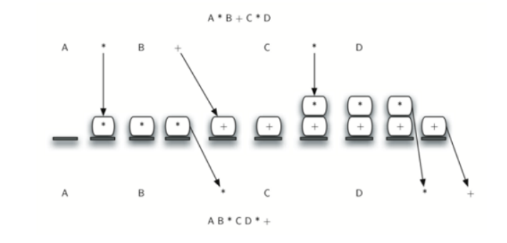

### Infix to Postfix

#### Code 1

```python
def infix_ke_postfix(ekspresi):
    precedence = {'+': 1, '-': 1, '*': 2, '/': 2, '^': 3}

    s = stack()
    output = []

    ekspresi = ekspresi.replace(" ", "")

    for token in ekspresi:
        if token.isalnum():
            output.append(token)
        elif token == '(':
            push(s, token) # Menggunakan fungsi push()
        elif token == ')':
            # Pop stack semua token sampai ditemukan kurung buka
            while not isEmpty(s) and peek(s) != '(':
                output.append(pop(s))
            if not isEmpty(s) and peek(s) == '(':
                pop(s)

        # Jika token adalah operator
        else:
            # Pop operator yang memiliki precedence lebih tinggi atau sama
            while (not isEmpty(s) and peek(s) != '(' and
                   precedence.get(peek(s), 0) >= precedence.get(token, 0)):
                output.append(pop(s))

            # Push token operator ke dalam stack
            push(s, token)

    # 3. Jika masih terdapat operator pada stack, pop sisanya
    while not isEmpty(s):
        output.append(pop(s))

    return "".join(output)

# ==========================================
# Contoh Penggunaan
# ==========================================
ekspresi_infix = "a * b + c / d"
hasil_postfix = infix_ke_postfix(ekspresi_infix)

print(f"Ekspresi Infix   : {ekspresi_infix}")
print(f"Ekspresi Postfix : {hasil_postfix}")
```

```
Ekspresi Infix   : a * b + c / d
Ekspresi Postfix : ab*cd/+
```

#### Code 2

```python
# fungsi menentukan precedence operator
def precedence(op):
    if op == '+' or op == '-':
        return 1
    elif op == '*' or op == '/':
        return 2
    elif op == '^':
        return 3
    else:
        return 0
```

```python
# fungsi mengecek apakah operand
def isOperand(ch):
    return ch.isalnum()   # huruf atau angka
```

```python
# fungsi utama konversi infix ke postfix
def infixToPostfix(infix):
    s = stack()
    output = ""

    for token in infix:

        # jika operand → langsung ke output
        if isOperand(token):
            output += token

        # jika kurung buka → push ke stack
        elif token == '(':
            push(s, token)

        # jika kurung tutup → pop sampai '('
        elif token == ')':
            while not isEmpty(s) and peek(s) != '(':
                output += pop(s)
            pop(s)  # buang '('

        # jika operator
        else:
            while (not isEmpty(s) and precedence(peek(s)) >= precedence(token)):
                output += pop(s)
            push(s, token)

    # pop semua operator sisa
    while not isEmpty(s):
        output += pop(s)

    return output
```

```python
infix = "a-b*c+d*e/f"
print("Infix   :", infix)
print("Postfix :", infixToPostfix(infix))
```

```
Infix   : a-b*c+d*e/f
Postfix : abc*-de*f/+
```

### **Evaluasi Ekspresi Postfix**

Seperti yang sudah dijelaskan sebelumnya, evaluasi untuk ekspressi aritmatika Postfix dilakukan setelah terdapat dua buah operand sebelum sebuah operator. Misalkan : 87+2*, yang berarti (8+7)*2=30, oleh karena itu berikut algoritma untuk mengevaluasi ekspressi aritmatika postfix :

1. baca string mulai dari kiri
2. Jika character yang dibaca adalah sebuah operand, maka push operand tersebut.
3. Jika character yang dibaca adalah sebuah operator, maka pop dua buah operand yang terdapat pada stack, operasikan dua buah operand tersebut dengan operator, dan push hasil operasinya
4. hasil akhir adalah angka terakhir yang terdapat di dalam stack

```python
def evaluatePost(postStr):
    operandStack=stack()
    operator='+-/*'
    for i in postStr:
        if i not in operator:
            push(operandStack,i)
        else:
            oprnd2=pop(operandStack)
            oprnd1=pop(operandStack)
            if i=='+':
                result=float(oprnd1)+float(oprnd2)
            elif i=='-':
                result=float(oprnd1)-float(oprnd2)
            elif i=='*':
                result=float(oprnd1)*float(oprnd2)
            else:
                result=float(oprnd1)/float(oprnd2)
            push(operandStack,result)
    return(pop(operandStack))
```

```python
print(evaluatePost('456*-'))
```

```
-26.0
```

### **Konversi Infix ke Prefix**

Berikut algoritma untuk konversi ekspressi aritmatik infix ke prefix :

1. Reverse Ekspresi infix
2. Tukar tanda kurung "(" menjadi ")" dan ")" menjadi "("
3. Ubah ke Postfix
4. Reverse Hasil

#### Code

```python
def infixToPrefix(ekspresi):
    # Reverse
    reverse1 = ""
    for token in ekspresi:
        if token == "(":
            reverse1 = ")" + reverse1
        elif token == ")":
            reverse1 = "(" + reverse1
        else:
            reverse1 = token + reverse1

    # Ubah menjadi postfix
    result = infix_ke_postfix(reverse1)

    # Reverse
    reverse2 = result[::-1]

    return reverse2
```

```python
infix = "a-b"
print("Infix   :", infix)
print("Prefix  :", infixToPrefix(infix))
```

```
Infix   : a-b
Prefix  : -ab
```